# Reproducible Research: Peer Assessment 1

## Loading and preprocessing the data

The first step in our analysis is to obtain the data. It is present in the current directory, so we can import it from the zip file.

```r
data <- read.csv(unz('activity.zip','activity.csv'),header=TRUE)
```

The missing values are already marked as ‘NA’. We should, however, convert the date column into date type, since it is currently of type character.

```r
str(data['date'])
```

```
## 'data.frame':    17568 obs. of  1 variable:
##  $ date: chr  "2012-10-01" "2012-10-01" "2012-10-01" "2012-10-01" ...
```

```r
data[,'date'] <- as.Date(as.character(data[,'date']),'%Y-%m-%d')

str(data['date'])
```

```
## 'data.frame':    17568 obs. of  1 variable:
##  $ date: Date, format: "2012-10-01" "2012-10-01" ...
```

## What is mean total number of steps taken per day?

Using the aggregate function to calculate total number of steps per day, based on the day:

```r
total <- aggregate(x=data$steps,by=list(data[,'date']),sum)
colnames(total) <- c('day','total.steps')
head(total,5)
```

```
##          day total.steps
## 1 2012-10-01          NA
## 2 2012-10-02         126
## 3 2012-10-03       11352
## 4 2012-10-04       12116
## 5 2012-10-05       13294
```

We can use this to plot a histogram of the table above:

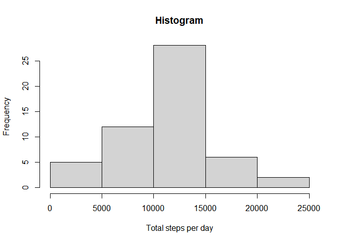

```r
hist(total[,'total.steps'],xlab='Total steps per day',main='Histogram')
```

The mean and median values of total steps taken per day is:

```r
print(paste('Mean:',toString(mean(total[,'total.steps'],na.rm=TRUE),width=11)))
```

```
## [1] "Mean: 10766.1...."
```

```r
print(paste('Median:',toString(median(total[,'total.steps'],na.rm=TRUE))))
```

```
## [1] "Median: 10765"
```

## What is the average daily activity pattern?

We can assess what the daily pattern of walking activity is. Grouping the data according to the time of day (5-minute interval):

```r
daily <- aggregate(x=data$steps,by=list(data[,'interval']),mean,na.rm=TRUE)
colnames(daily) <- c('interval','average.steps')
head(daily,5)
```

```
##   interval average.steps
## 1        0     1.7169811
## 2        5     0.3396226
## 3       10     0.1320755
## 4       15     0.1509434
## 5       20     0.0754717
```

We can now plot a time series plot to identify the daily pattern of walking:

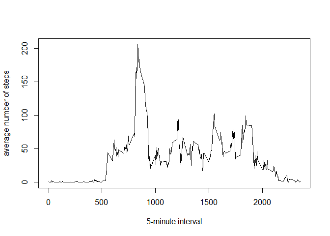

```r
plot(daily$interval,daily$average.steps,type='l',xlab='5-minute interval',ylab='average number of steps')
```

Identifying which interval contains the maximum number of steps, on average:

```r
daily[which(daily$average.steps==max(daily$average.steps)),]
```

```
##     interval average.steps
## 104      835      206.1698
```

That corresponds to 8:35 AM.

## Imputing missing values

We can calculate how many missing values we have in the table:

```r
sum(is.na(data$steps))
```

```
## [1] 2304
```

We can impute these numbers using the median number of steps of that particular time interval:

```r
dailymedian <- aggregate(x=data$steps,by=list(data[,'interval']),median,na.rm=TRUE)
colnames(dailymedian) <- c('interval','median.steps')

imputed <- c()

for (r in 1:nrow(data)) {
  if (is.na(data[r,'steps'])){
    imputed[r] <- dailymedian[dailymedian$interval==data[r,'interval'],'median.steps']
    } else {
    imputed[r] <- data[r,'steps']
    }
}
```

We can create a new dataset containing that column

```r
newdata <- cbind(imputed, as.character(data$date),data$interval)
colnames(newdata) <- colnames(data)
newdata <- data.frame(newdata)
newdata$date <- as.Date(newdata$date)
newdata$steps <- as.numeric(newdata$steps)
newdata$interval <- as.integer(newdata$interval)

head(newdata,5)
```

```
##   steps       date interval
## 1     0 2012-10-01        0
## 2     0 2012-10-01        5
## 3     0 2012-10-01       10
## 4     0 2012-10-01       15
## 5     0 2012-10-01       20
```

We can recalculate mean and median of steps per day and see if there is substantial difference:

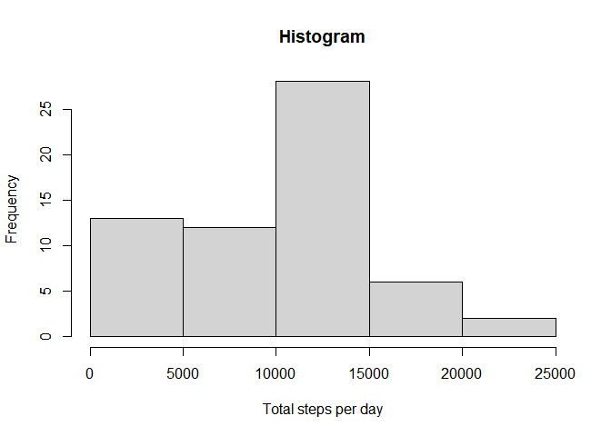

```r
totalna <- aggregate(x=newdata$steps,by=list(newdata[,'date']),sum)
colnames(totalna) <- c('day','total.steps')
hist(totalna[,'total.steps'],xlab='Total steps per day',main='Histogram')
```

```r
print(paste('Mean:',toString(mean(totalna[,'total.steps'],na.rm=TRUE),width=11)))
```

```
## [1] "Mean: 9503.86...."
```

```r
print(paste('Median:',toString(median(totalna[,'total.steps'],na.rm=TRUE))))
```

```
## [1] "Median: 10395"
```

The histogram now has a left skew: some days had no recorded number of steps or they had lots of missing values. When we impute these with the median number of steps for a given interval of the day, that increases the total number of steps for some days, usually falling below 10,000 steps per day. This effectively alters the mean and median number of steps per day, decreasing them.

## Are there differences in activity patterns between weekdays and weekends?

We can create a new factor in the table that indicates whether the day was a weekday or not.

```r
weekdays1 <- c('Monday','Tuesday','Wednesday','Thursday','Friday')
newdata$weekend <- factor(weekdays(newdata$date) %in% weekdays1,levels=c(TRUE,FALSE),labels=c('weekday','weekend'))
```

We can then make an updated table with the average number of steps grouped across weekdays and weekend days. Then we can plot them as a time series.

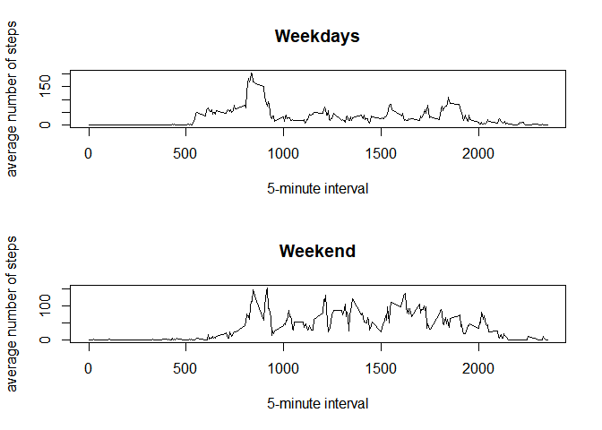

```r
dailyweek <- aggregate(x=newdata[newdata$weekend=='weekday',]$steps,by=list(newdata[newdata$weekend=='weekday','interval']),mean,na.rm=TRUE)
dailyweekend <- aggregate(x=newdata[newdata$weekend=='weekend',]$steps,by=list(newdata[newdata$weekend=='weekend','interval']),mean,na.rm=TRUE)
colnames(dailyweek) <- c('interval','average.steps')
colnames(dailyweekend) <- c('interval','average.steps')
par(mfrow=c(2,1))
plot(dailyweek$interval,dailyweek$average.steps,type='l',xlab='5-minute interval',ylab='average number of steps',main='Weekdays')
plot(dailyweekend$interval,dailyweekend$average.steps,type='l',xlab='5-minute interval',ylab='average number of steps',main='Weekend')
```